# Problem Set 3

Author

## Setting up a reusable theme

For this problem set, we will create a reusable theme that we can apply to each plot. This is similar to the process that you would use when designing slides for manuscripts, posters, or presentations. In those cases, you would likely make the plots first and then modify them to fit.

Here we will make the theme first, since we will use it for some plots in this problem set. Additionally, while you would be outputting files as PDF or an image format normally, we’ll just use the native Quarto html rendering. We can still make a theme, and it works the same.

The code chunk below makes a basic plot with some points. We don’t care now about the contents of the plot; we will just use it to make a reusable theme. In the chunk below add the following theme elements:

- Bold the axis **titles**
- Italicize the axis *labels*
- Resize the axis titles and labels so that the titles are larger and the labels smaller, such they they look proportionally correct in the rendered document. There is no one correct size. Choose something that looks good to you. Note that the plot in the RStudio plotting window might not look very good although the rendered document does.

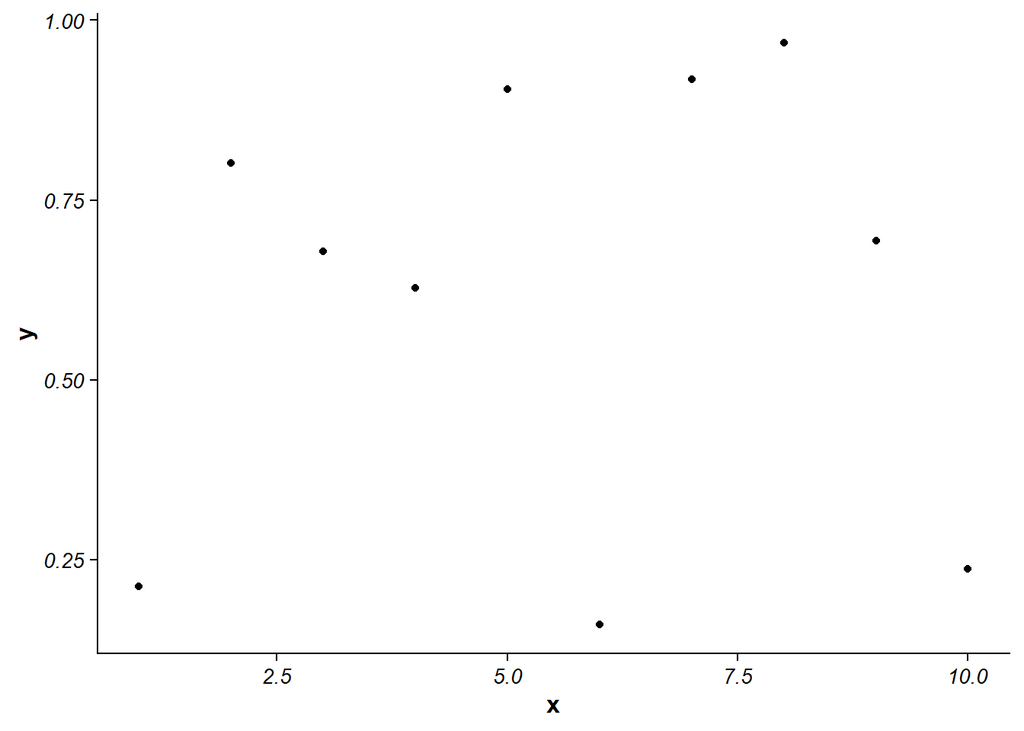

```r
ggplot(data = tibble(x = 1:10, y = runif(10)),
       aes(x, y)) +
  geom_point() +
  theme(axis.title = element_text(face = "bold", size = 12),
        axis.text = element_text(face = "italic", size = 10))
```

Now put the `theme()` elements into a list and assign it to an object that so you can reuse the theme. Verify that you generate the same plot as above when you add your plot theme.

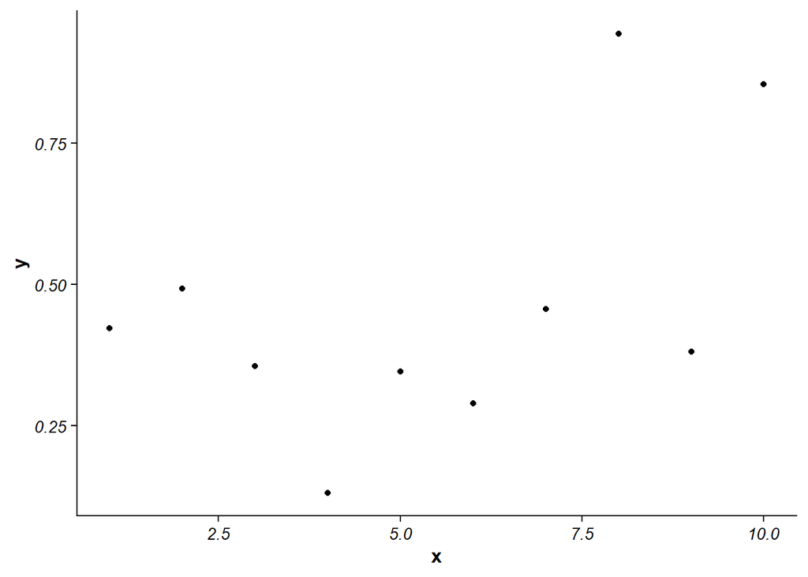

```r
# FIXME
mytheme <- list(
  theme(axis.title = element_text(face = "bold", size = 12),
        axis.text = element_text(face = "italic", size = 10)
  ))

ggplot(data = tibble(x = 1:10, y = runif(10)),
       aes(x, y)) +
  geom_point() +
  mytheme
```

## Floristic composition diversity in Bangalore, India[^1]

The file `Floristic_composition_and_Diversity.csv` contains data on the sizes of about 1,500 trees on the campus of the University of Agricultural Sciences, Bangalore. We are interested in exploring the relationship between diameter and height in the different families of trees represented.

- Read in the file and convert `Diameter_cm` (diameter in centimeters) to meters, so that the height, which is measured in meters, will be on the same scale.
- Create a factor from `Family` wherein the order of the factors is the relative abundance of trees within each family. The order should be Myrtaceae, Fabaceae, Santalaceae, etc.

```r
# FIXME
D <- read_csv("../Data/Floristic_composition_and_Diversity.csv",
              show_col_types = FALSE) |>
  mutate(Diameter_m = Diameter_cm / 100,
         Family = fct_infreq(Family))
```

Create a plot of height predicted by diameter, and color the points by family. Additionally

- Scale the x and y axes using log<sub>10</sub>
- Facet wrap the plots by family. You should have a 3 x 4 grid of plots. The top row should be Myrtaceae, Fabaceae, Santalaceae, and Bignoniaceae.

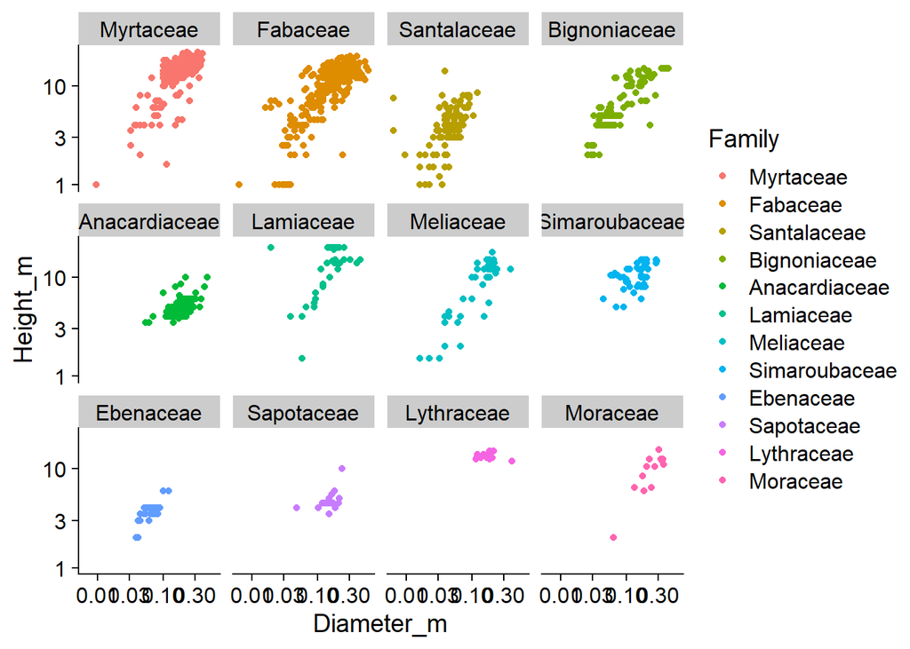

```r
# FIXME
ggplot(D, aes(x = Diameter_m, y = Height_m, color = Family)) +
  geom_point() +
  scale_x_log10() +
  scale_y_log10() +
  facet_wrap("Family")
```

We’d like to add a regression line for all the points (as opposed to a Family-specific regression). Fit a linear model where log<sub>10</sub>(Height) is modeled by log<sub>10</sub>(Diameter). Extract the intercept and slope coefficients for this model. We will use them to add a line to the plot.

```r
# FIXME
fm <- lm(log10(Height_m) ~ log10(Diameter_m), data = D)
coefs <- coef(fm)
coefs
```

```
      (Intercept) log10(Diameter_m)
        1.5966671         0.7284462
```

Add a line to the plot as the first layer matching the slope and intercept for the fitted model above. Each facet should have the same line, which should be behind the points.

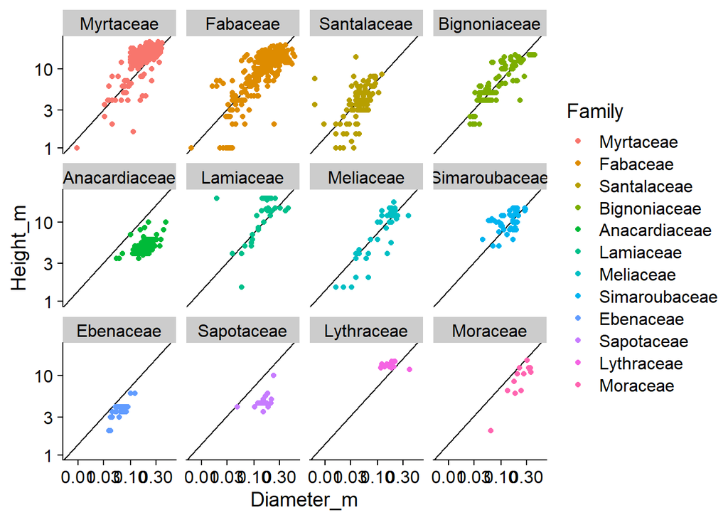

```r
# FIXME
ggplot(D, aes(x = Diameter_m, y = Height_m, color = Family)) +
  geom_abline(slope = coefs[2], intercept = coefs[1]) +
  geom_point() +
  scale_x_log10() +
  scale_y_log10() +
  facet_wrap("Family")
```

Finally, we can fix up the appearance of the plot.

- Remove the color legend. Since we have labeled facets, we don’t need it.
- Write informative axis titles
- Add your theme from above.

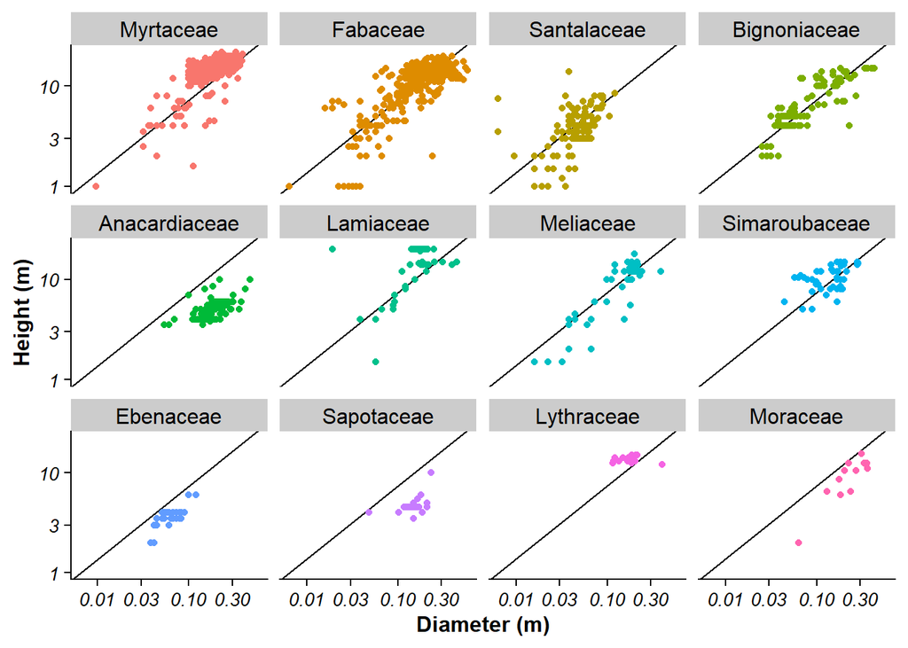

```r
# FIXME
ggplot(D, aes(x = Diameter_m, y = Height_m, color = Family)) +
  geom_abline(slope = coefs[2], intercept = coefs[1]) +
  geom_point() +
  scale_x_log10() +
  scale_y_log10() +
  facet_wrap("Family") +
  theme(legend.position = "none") +
  labs(x = "Diameter (m)", y = "Height (m)") +
  mytheme
```

## Shark physiology

The Blacktip reef shark (*Carcharhinus melanopterus*) is an apex predator of many oceans. The combined changes in global temperature and CO<sub>2</sub> levels might impact of the actiity and thus survival of this species. Bouyoucos et al (2020)[^2] measured (among other traits) activity level in two different levels of temperature and CO<sub>2</sub> concentrations (pCO<sub>2</sub>).

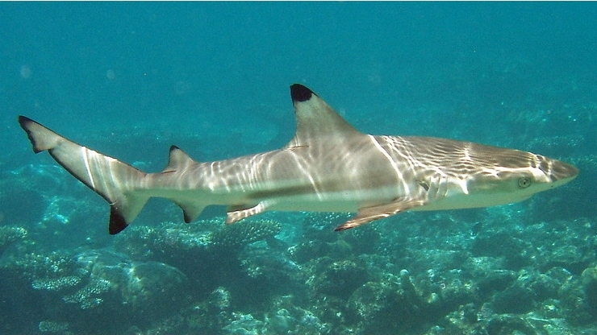

Read in the `reef_shark.csv` file. You will find that the units are included in the data columns (e.g., “31C”). This is not ideal (and not our recommendation for storing data), because we want to treat these data as numbers, although we will convert them to factors.

```r
# FIXME
Shark <- read_csv("../Data/reef_sharks.csv",
                  show_col_types = FALSE) |>
  mutate(temp = str_remove(temp, "C") |> factor(),
         pco2 = str_remove(pco2, "uatm") |> factor(levels = c(650, 1050)))
```

Make an initial plot of activity predicted by CO<sub>2</sub> level, with point color determined by temperature.

- Make the points larger than the default
- Add some jitter to the points to avoid overplotting.
  - Make the jitter repeatable.

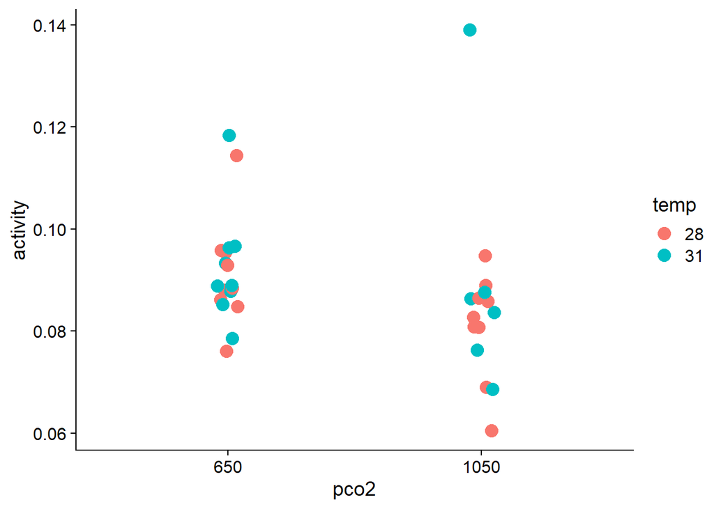

```r
# FIXME
ggplot(Shark, aes(y = activity, x = pco2, color = temp)) +
  geom_point(size = 4, position = position_jitter(width = 0.05, seed = 48727))
```

We would like to label the one extreme point in the 1050 uATM CO<sub>2</sub> data. First we have to find that point in the data.

- Arrange the data descending by activity. Note the `shark` ID for the extreme value near 0.14.
- Create a new column that we will use for labeling. If `shark` matches the ID above, put the ID in a string. Otherwise, assign the empty string `""`.
- Use `geom_text_repel()` from the `ggrepel` package to add a label.
  - Add a little padding to the box around the point to offset the label a bit.
  - Make the position reproducible

```r
# FIXME
library(ggrepel)

Shark |> arrange(desc(activity)) |> slice(1)
```

```
# A tibble: 1 × 5
  shark temp  pco2  group activity
  <chr> <fct> <fct> <chr>    <dbl>
1 Cm47  31    1050  d        0.139
```

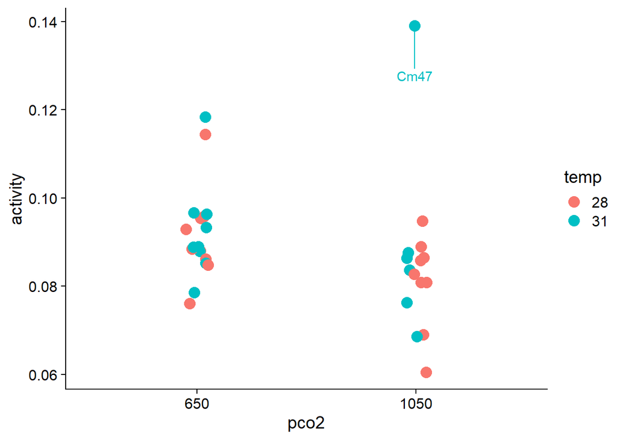

```r
Shark <- Shark |>
  mutate(Label = if_else(shark == "Cm47", "Cm47", ""))

ggplot(Shark, aes(y = activity, x = pco2, color = temp, label = Label)) +
  geom_point(size = 4, position = position_jitter(width = 0.05, seed = 4872)) +
  geom_text_repel(box.padding = 2.5,
                  position = position_jitter(width = 0.05, seed = 4872),
                  seed = 1736)
```

Finally, add some finishing touches to the plot:

- Add informative axis titles. The x-axis title should read “pCO<sub>2</sub>”, with the 2 subscripted. Use whatever method you want to format this title.
- Rename the color scale to read “Temperature (C)”.
- Add your theme from above.

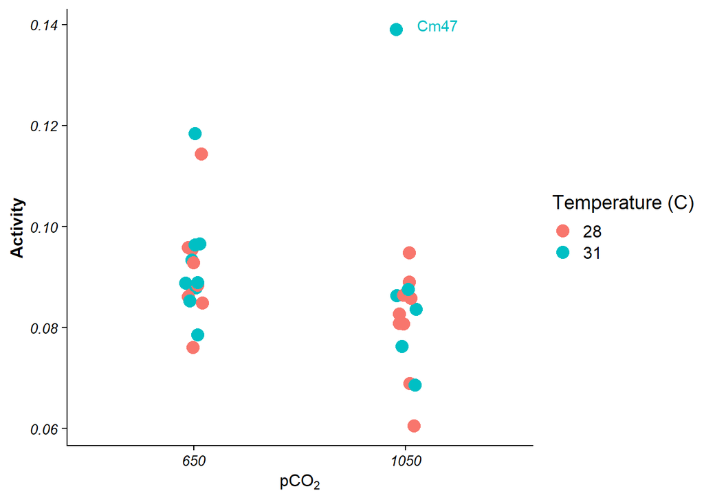

```r
# FIXME
ggplot(Shark, aes(y = activity, x = pco2, color = temp, label = Label)) +
  geom_point(size = 4, position = position_jitter(width = 0.05, seed = 48727)) +
  geom_text_repel(box.padding = 0.5, seed = 17346) +
  labs(y = "Activity", x = expression(pCO[2])) +
  scale_color_discrete(name = "Temperature (C)") +
  mytheme
```

You’ll find that formatting math on axis titles doesn’t often work well with text formatting. That’s an unfortunate side effect.

## Spiny damselfish respirometry

Respirometry is a technique for measuring the oxygen consumption and CO<sub>2</sub> production in living organisms. Rodgers[^3] studied six adult spiny chromis damselfish (*Acanthochromis polyacanthus*) to compare closed system and flow-through respirometry techniques (basically to see if the two techniques gave similar measurements).

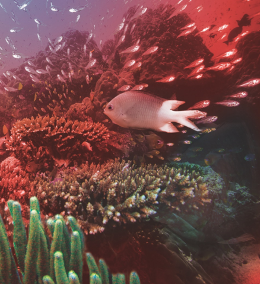

The file `A_polyacanthus_respirometry.csv` contains the data. Each fish (A - F) was measured in each configuration (“Static” or “Recirculation”) across a time range (0 to 408 minutes). Because of the complex time-series nature of the data, the organization is a little challenging.

Each row represents measures at a single time. Each fish/configuration combination is a column. The values in the columns are oxygen consumption for each fish measured in mg of O<sub>2</sub> consumed kg<sup>-1</sup> h<sup>-1</sup> (milligrams of oxygen per kilogram per hour). Representing the measures thus accounts for size differences between individuals.

We will start by organizing the data into a format that we can use.

- Read in the file `A_polyacanthus_respirometry.csv`
- Pivot the data to long format, keeping the `Time_min` column. You will now have 3 columns.
- Separate the resulting `name` column into “Treatment” and “ID”, by splitting on “-”
- Mutate `Treatment` into a factor, with “Static” as the first level.
- Mutate `ID` to a factor

```r
# FIXME
D <- read_csv("../Data/A_polyacanthus_respirometry.csv",
              show_col_types = FALSE)

D_long <- D |>
  pivot_longer(cols = -Time_min, values_to = "O2_Consumption") |>
  separate(col = name, into = c("Treatment", "ID"), sep = "-") |>
  mutate(Treatment = factor(Treatment, levels = c("Static", "Recirculation")),
         ID = factor(ID))
```

The first few rows of the long data should look like:

```
# A tibble: 216 × 4
   Time_min Treatment     ID    O2_Consumption
      <dbl> <fct>         <fct>          <dbl>
 1        0 Recirculation A               2.42
 2        0 Recirculation B               4.13
 3        0 Recirculation C               3.91
 4        0 Recirculation D               5.10
 5        0 Recirculation E               4.06
 6        0 Recirculation F               3.03
 7        0 Static        A               3.85
 8        0 Static        B               2.62
 9        0 Static        C               3.59
10        0 Static        D               4.05
```

Make a plot of oxygen consumption by time. Color the lines by ID, set the linetype (solid and dashed) by Treatment, and facet the plot in a grid by ID. Make a 6 x 1 plot.

- Title the axes appropriately. The y-axis should read: Oxygen consumption (mg O<sub>2</sub> kg<sup>-1</sup> h<sup>-1</sup>

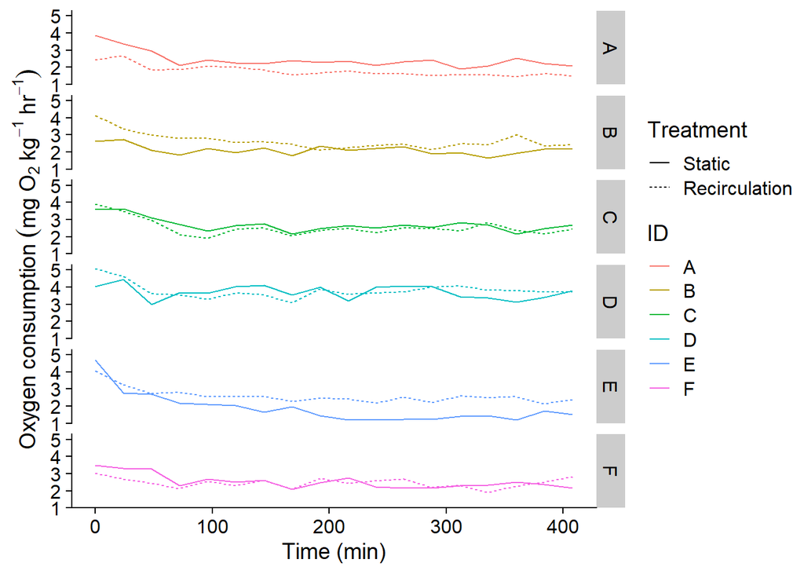

```r
# FIXME
ggplot(D_long,
       aes(x = Time_min, y = O2_Consumption,
           linetype = Treatment, color = ID)) +
  geom_line() +
  facet_grid(ID ~ .) +
  labs(y = expression(Oxygen~consumption~(mg~O[2]~kg^-1~hr^-1)),
       x = "Time (min)")
```

Inspecting the plot, it appears that the values have stabilized by about 120 minutes. Plot the reaction norm at 120 min.

- Filter the long data to only include rows for 120 minutes
- Plot oxygen consumption by treatment. Connect the points for a single individual with lines.
- Title the axes appropriately.

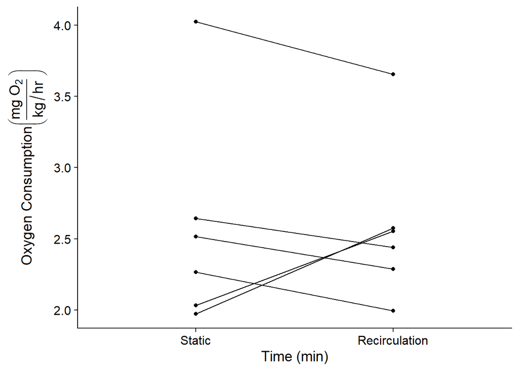

```r
# FIXME
D_120 <- D_long |>
  filter(Time_min == 120)

ggplot(D_120, aes(x = Treatment, y = O2_Consumption, group = ID)) +
  geom_point() +
  geom_line() +
  labs(y = TeX(r"(Oxygen Consumption $\left( \frac{mg~O_2}{kg / hr} \right)$)"),
       x = "Time (min)")
```

Add a point and bars for the bootstrapped 95% confidence interval of the mean.

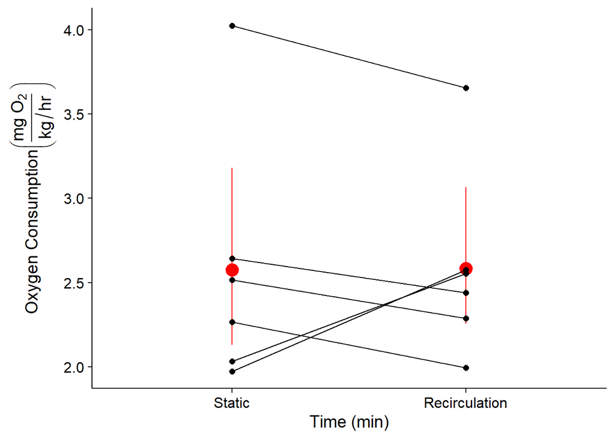

```r
# FIXME
ggplot(D_120, aes(x = Treatment, y = O2_Consumption, group = ID)) +
  stat_summary(aes(group = -1),
               fun.data = "mean_cl_boot",
               color = "red",
               size = 1) +
  geom_point(size = 2) +
  geom_line() +
  labs(y = TeX(r"(Oxygen Consumption $\left( \frac{mg~O_2}{kg / hr} \right)$)"),
       x = "Time (min)")
```

Since these are paired data, we can calculate the per-fish difference between the treatments and test whether the difference is significantly different from zero (paired *t*-test).

- Drop the `Time_min` column (all the points are at 120 min)
- Pivot the data to wide format, taking the names from “Treatment” and values from “O2_Consumption”. The data should now have 6 rows and 3 columns.
- Create a new variable that is the difference of Static - Recirculation
- Run a `t.test()` comparing the difference to a mean (`mu`) of 0.

```r
# FIXME
D_diff <- D_120 |>
  select(-Time_min) |>
  pivot_wider(names_from = "Treatment", values_from = "O2_Consumption") |>
  mutate(d = Static - Recirculation)

t.test(D_diff$d, mu = 0)
```

```
    One Sample t-test

data:  D_diff$d
t = -0.047474, df = 5, p-value = 0.964
alternative hypothesis: true mean is not equal to 0
95 percent confidence interval:
 -0.4613986  0.4446652
sample estimates:
   mean of x
-0.008366667
```

## Snow in Grand Rapids, Michigan

Grand Rapids, Michigan can receive a large amount of snow in the winter (which can last a long time). The file `GR_Snow.csv` has monthly snow totals for over 100 years. The snow “season” starts in July of one year and ends in Jun of the following year.

To start exploring patterns of snowfall, load the data and make a plot of `Total` by `SeasonStart`. This is total seasonal snowfall by year.

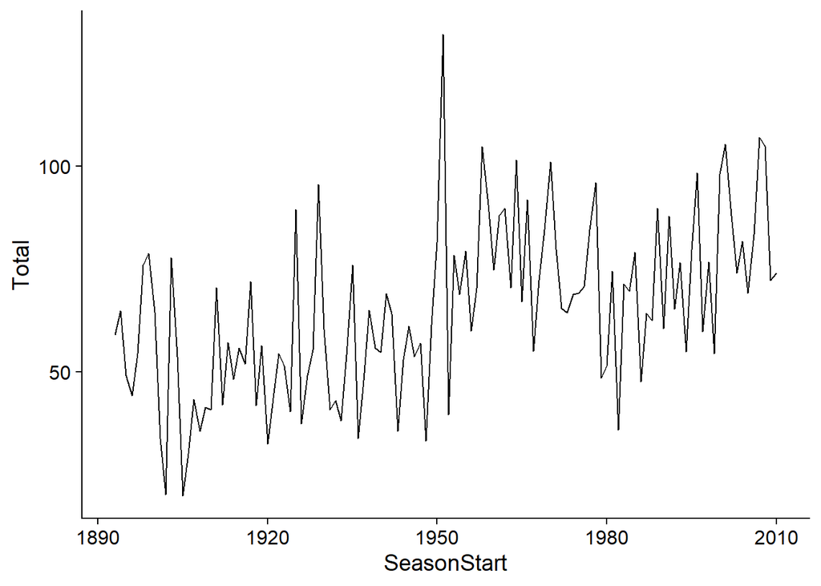

```r
# FIXME
GR <- read_csv("../Data/GR_Snow.csv",
               show_col_types = FALSE)

ggplot(GR, aes(x = SeasonStart, y = Total)) +
  geom_line()
```

We’ll work with Date objects for this problem. Using the `lubridate` package makes this process pretty easy. `lubridate` has functions to automatically create Date objects from strings.

```r
library(lubridate)
ymd("2022-01-31")
```

```
[1] "2022-01-31"
```

```r
ym("2022-Jan")
```

```
[1] "2022-01-01"
```

We will use the latter `ym()` to create Date objects for Year/Month combinations.

- Filter out only observations from 1960 and later (just to have less data to work with)
- Drop `SeasonEnd` and `Total`. This will leave only the year and columns for each month
- Pivot the data to long format, keeping `SeasonStart`. Convert column names to “Month” and values to “Snow”
- Create a new “Date” variable that combines `SeasonStart` and `Month` by pasting them together with “-” and passing to `ym()`

```r
# FIXME
GR_long <- GR |>
  filter(SeasonStart >= 1960) |>
  select(-SeasonEnd, -Total) |>
  pivot_longer(cols = -SeasonStart, names_to = "Month", values_to = "Snow") |>
  mutate(Date = ym(paste(SeasonStart, Month, sep = "-")))
```

The head of your data should look like:

```
# A tibble: 612 × 4
   SeasonStart Month  Snow Date
         <dbl> <chr> <dbl> <date>
 1        1960 Jul     0   1960-07-01
 2        1960 Aug     0   1960-08-01
 3        1960 Sep     0   1960-09-01
 4        1960 Oct     0   1960-10-01
 5        1960 Nov     5.9 1960-11-01
```

Make a plot of Snow by Date. This is the monthly total from 1960 to 2010.

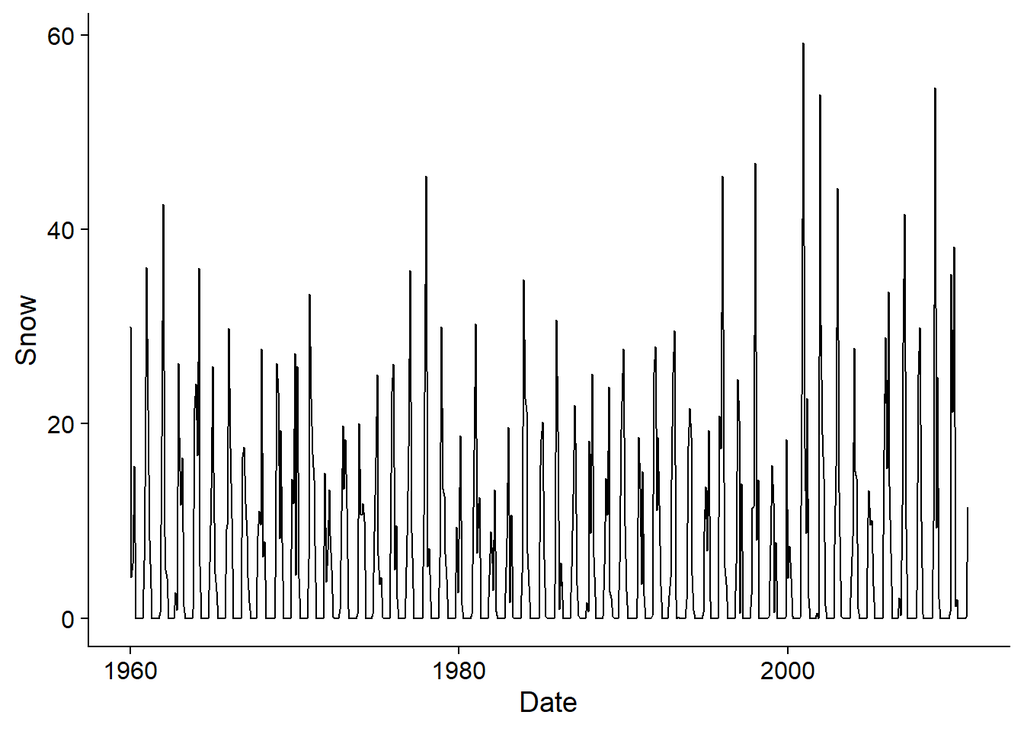

```r
# FIXME
ggplot(GR_long, aes(x = Date, y = Snow)) +
  geom_line()
```

To make the data a little easier to follow, add alternating blocks of gray roughly by decade:

- July 1, 1960 to June 30, 1970
- July 1, 1980 to June 30, 1990
- July 1, 2000 to June 30, 2010

You will need to create a separate tibble containg the start and end dates for the rectangles and add the shading with `geom_rect()`.

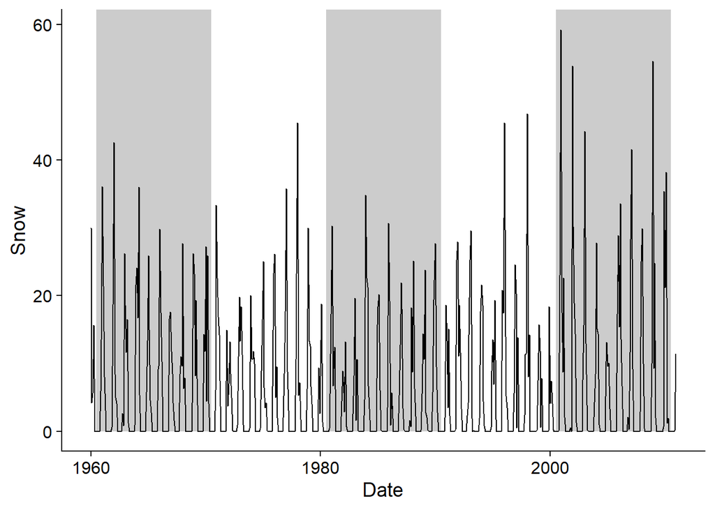

```r
# FIXME
Decades <- tribble(
  ~ Start, ~ End,
  ymd("1960-07-01"), ymd("1970-06-30"),
  ymd("1980-07-01"), ymd("1990-06-30"),
  ymd("2000-07-01"), ymd("2010-06-30")
)

ggplot() +
  geom_rect(data = Decades,
            aes(xmin = Start, xmax = End,
                ymin = 0, ymax = Inf),
            fill = "gray80") +
  geom_line(data = GR_long,
            aes(x = Date, y = Snow))
```

Finally, we want to add a text label at the maximum snowfall. Find the maximum.

```r
# FIXME
GR_long |> arrange(desc(Snow)) |> slice(1)
```

```
# A tibble: 1 × 4
  SeasonStart Month  Snow Date
        <dbl> <chr> <dbl> <date>
1        2000 Dec    59.2 2000-12-01
```

- Add a red point at the maximum and a text annotation with the Month, Year and snowfall value.
- Make the x-axis labels in 5-year increments (1960, 1965, 1970, etc.)

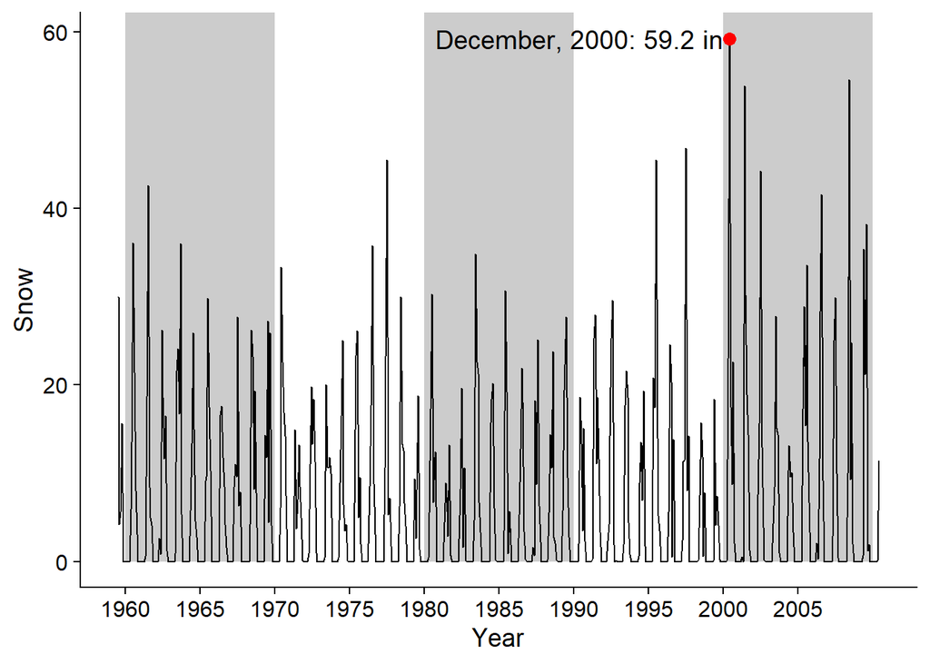

```r
# FIXME
ggplot() +
  geom_rect(data = Decades,
            aes(xmin = Start, xmax = End,
                ymin = 0, ymax = Inf),
            fill = "gray80") +
  geom_line(data = GR_long,
            aes(x = Date, y = Snow)) +
  geom_point(data = GR_long |> arrange(desc(Snow)) |> slice(1),
             aes(x = Date, y = Snow),
             color = "red",
             size = 3) +
  annotate(geom = "text",
           label = "December, 2000: 59.2 in",
           x = ym("2000-Jul"),
           y = 59.2,
           hjust = 1,
           size = 5) +
  scale_x_date(breaks = seq(ym("1960-Jul"), ym("2010-Jun"), by = "5 years"),
               date_labels = "%Y",
               name = "Year")
```

## Footnotes

[^1]: T S Sumanth. 2022. Floristic composition and Diversity, doi: 10.17632/7y8y2wf7b4.1
[^2]: Bouyoucos, I. A., S.-A. Watson, S. Planes, C. A. Simpfendorfer, G. D. Schwieterman, N. M. Whitney, and J. L. Rummer. 2020. The power struggle: assessing interacting global change stressors via experimental studies on sharks. *Sci. Rep.* 10:19887.
[^3]: Rodgers, Giverny (2018): A comparison of closed system and flow-through respirometry techniques using adult *Acanthochromis polyacanthus*. James Cook University. https://doi.org/10.4225/28/5ab08a55baf15